# Searching Density Bursting Subgraphs in the Facebook Wall Posts dataset

## Necessary imports

```python
# import external libraries
import numpy as np
import pandas as pd
import networkx as nx
import matplotlib.pyplot as plt

# import custom classes and functions
from src import Graph, TemporalGraph, find_density_bursting_subgraph
```

## Data preparation

First off, load the data.

```python
with open("data/sample.txt", "r") as f:
    s = f.read()
connections = np.array([x.split(" ") for x in s.split("\n")], dtype=int)
```

Look at the dataset and gather some information about it.

```python
# top rows
df = pd.DataFrame(connections, columns=['facebook_user_1', 'facebook_user_1', 'day'])
df.head(10)
```

|  | facebook_user_1 | facebook_user_1 | day |
| --- | --- | --- | --- |
| 0 | 7512 | 5790 | 31 |
| 1 | 4355 | 8271 | 31 |
| 2 | 21964 | 8271 | 31 |
| 3 | 6106 | 26471 | 31 |
| 4 | 28994 | 20827 | 31 |
| 5 | 4355 | 28994 | 30 |
| 6 | 4355 | 20827 | 30 |
| 7 | 6106 | 10695 | 30 |
| 8 | 22165 | 20827 | 30 |
| 9 | 13149 | 14887 | 30 |

We show some statistics, although here, they don't really make sense.

```python
df.describe()
```

|  | facebook_user_1 | facebook_user_1 | day |
| --- | --- | --- | --- |
| count | 180.000000 | 180.000000 | 180.000000 |
| mean | 13838.516667 | 15902.288889 | 15.244444 |
| std | 8542.620891 | 8524.347692 | 9.421610 |
| min | 407.000000 | 407.000000 | 0.000000 |
| 25% | 6106.000000 | 8271.000000 | 7.000000 |
| 50% | 11228.000000 | 14887.000000 | 15.500000 |
| 75% | 21964.000000 | 22098.000000 | 23.000000 |
| max | 28994.000000 | 28994.000000 | 31.000000 |

We grab a sample. More precisely, we select the bottom rows of the dataset which correspond to the most ancient wall posts in ascending order.

```python
max_timestep = 20
connections = connections[np.where(connections[:, 2] < max_timestep)]
```

```python
users = np.unique(connections[:, :2])
n_users = users.shape[-1]
new_nodes = dict(np.vstack((users, np.arange(n_users))).T)
```

The row data consists of edge lists (one for each timestep). We transform it into a temporal graph.

```python
snapshots = []
for t in range(max_timestep):
    adj_mat = np.zeros((n_users, n_users))
    for x in connections[np.where(connections[:, 2] == t), :2][0]:
        i, j = x
        adj_mat[new_nodes[i], new_nodes[j]] += 1
        adj_mat[new_nodes[j], new_nodes[i]] += 1
    snapshots += [Graph(list(new_nodes.values()), adj_mat)]
```

```python
t_graph = TemporalGraph(snapshots, verbose=True)
```

```
# timesteps : 20
vertices : [0, 1, 2, 3, 4, 5, 6, 7, 8, 9, 10, 11, 12, 13, 14, 15, 16, 17, 18, 19, 20, 21, 22, 23, 24]
```

## Graph visualization

Once we have a temporal graph, we can visualize its snapshots and accumulated graphs. We can play with it by changing the value of t and re-running the three followig cells.

```python
# select a timestep
t = 6

if True:
    # to plot the accumulated graph
    graph = np.sum(t_graph[:t])
else:
    # to plot the snapshot
    graph = np.sum(t_graph[t])
```

```python
edges = [(i, j, {
    "weight": graph.adjacency_matrix[i, j]
}) for i in range(graph.n_vertices) for j in range(i)
         if graph.adjacency_matrix[i, j]]

net = nx.Graph()
net.add_edges_from(edges)
```

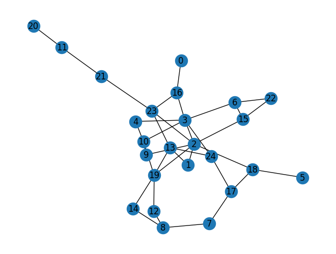

```python
pos = nx.spring_layout(net)
nx.draw(net, pos, with_labels=True)
plt.show()
```

## Running the algorihm

```python
nodes, t_b, t_e = find_density_bursting_subgraph(t_graph, theta=5)
```

```python
print(f"nodes : {nodes}\nT = ({t_b}, {t_e}]")
```

```
nodes : (0, 6)
T = (7, 11]
```